# projet

```python
import numpy as np
import pandas as pd
import matplotlib.pyplot as plt

%matplotlib inline
```

```python
import os
for f in os.listdir():
    print(f)
```

```
.ipynb_checkpoints
ch4_mm_gl.csv
co2_mm_mlo.csv
n2o_mm_gl.csv
projet.ipynb
sf6_mm_gl.csv
```

```python
ch4 = pd.read_csv('ch4_mm_gl.csv', comment='#')
co2 = pd.read_csv('co2_mm_mlo.csv', comment='#')
n2o = pd.read_csv('n2o_mm_gl.csv', comment='#')
sf6 = pd.read_csv('sf6_mm_gl.csv', comment='#')
ch4.head()
```

|  | year | month | decimal | average | average_unc | trend | trend_unc |
| --- | --- | --- | --- | --- | --- | --- | --- |
| 0 | 1983 | 7 | 1983.542 | 1625.98 | 2.39 | 1635.19 | 1.46 |
| 1 | 1983 | 8 | 1983.625 | 1628.04 | 2.93 | 1635.68 | 1.39 |
| 2 | 1983 | 9 | 1983.708 | 1638.41 | 2.20 | 1636.23 | 1.31 |
| 3 | 1983 | 10 | 1983.792 | 1644.82 | 1.47 | 1636.85 | 1.23 |
| 4 | 1983 | 11 | 1983.875 | 1642.59 | 0.82 | 1637.54 | 1.15 |

```python
for nom, df in [('CH4', ch4), ('CO2', co2), ('N2O', n2o), ('SF6', sf6)]:
    nb = len(df)
    debut = f"{df['month'].iloc[0]}/{df['year'].iloc[0]}"
    fin = f"{df['month'].iloc[-1]}/{df['year'].iloc[-1]}"
    print(f"{nom} : {nb} observations, de {debut} à {fin}")
```

```
CH4 : 511 observations, de 7/1983 à 1/2026
CO2 : 818 observations, de 3/1958 à 4/2026
N2O : 301 observations, de 1/2001 à 1/2026
SF6 : 343 observations, de 7/1997 à 1/2026
```

```python
ch4 = ch4[['month', 'average']]
co2 = co2[['month', 'average']]
n2o = n2o[['month', 'average']]
sf6 = sf6[['month', 'average']]

ch4.head()
```

|  | month | average |
| --- | --- | --- |
| 0 | 7 | 1625.98 |
| 1 | 8 | 1628.04 |
| 2 | 9 | 1638.41 |
| 3 | 10 | 1644.82 |
| 4 | 11 | 1642.59 |

Le dioxyde de carbone (CO₂) est le gaz le plus connu. Il vient surtout de la combustion des énergies fossiles (pétrole, charbon, gaz) et de la déforestation. C'est le principal responsable du réchauffement d'origine humaine, car il est présent en grande quantité. Il se mesure en ppm.

Le méthane (CH₄) provient de l'élevage, des rizières, des décharges et des fuites de gaz naturel. À quantité égale, il retient beaucoup plus de chaleur que le CO₂, mais il est présent en plus petite quantité et reste moins longtemps dans l'atmosphère. Il se mesure en ppb.

Le protoxyde d'azote (N₂O) vient principalement des engrais utilisés en agriculture. C'est un gaz très puissant qui reste très longtemps dans l'atmosphère, et il abîme aussi la couche d'ozone. Il se mesure également en ppb.

L'hexafluorure de soufre (SF₆) est un gaz uniquement industriel, utilisé comme isolant dans le matériel électrique haute tension. C'est le gaz à effet de serre le plus puissant connu et il peut rester des milliers d'années dans l'atmosphère. Mais il est présent en quantité minuscule, c'est pourquoi on le mesure en ppt.

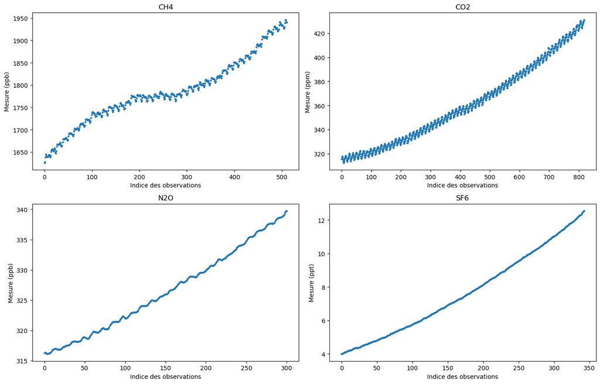

```python
fig, axes = plt.subplots(2, 2, figsize=(14, 9))

donnees = [('CH4', ch4, 'ppb'), ('CO2', co2, 'ppm'),
           ('N2O', n2o, 'ppb'), ('SF6', sf6, 'ppt')]

for ax, (nom, df, unite) in zip(axes.flat, donnees):
    ax.scatter(range(len(df)), df['average'], s=5)
    ax.set_title(nom)
    ax.set_xlabel("Indice des observations")
    ax.set_ylabel(f"Mesure ({unite})")

plt.tight_layout()
plt.show()
```

Interprétation des nuages de points

Le CO₂ et le CH₄ montent avec des petites vagues régulières qui se répètent chaque année(forme en dents de scie) : ce sont des variations saisonnières. Le N₂O a des ondulations très faibles et le SF₆ monte de façon lisse, sans motif répété. Les deux gaz clairement saisonniers sont donc le CO₂ et le CH₄. Ces variations viennent surtout de la végétation : les plantes absorbent du CO₂ au printemps/été et le relâchent en automne/hiver, ce qui crée un cycle annuel.

```python
# Moyenne mobile d'ordre 6 sur le CO2
x = co2['average'].values
n = len(x)
mm = [None] * n
for t in range(6, n - 6):
    valeur = (0.5 * x[t-6] + x[t-5] + x[t-4] + x[t-3] + x[t-2] + x[t-1]
              + x[t] + x[t+1] + x[t+2] + x[t+3] + x[t+4] + x[t+5] + 0.5 * x[t+6])
    mm[t] = valeur / 12

co2['mm'] = mm
co2.head(10)
```

|  | month | average | mm |
| --- | --- | --- | --- |
| 0 | 3 | 315.71 | NaN |
| 1 | 4 | 317.45 | NaN |
| 2 | 5 | 317.51 | NaN |
| 3 | 6 | 317.27 | NaN |
| 4 | 7 | 315.87 | NaN |
| 5 | 8 | 314.93 | NaN |
| 6 | 9 | 313.21 | 315.409167 |
| 7 | 10 | 312.42 | 315.459583 |
| 8 | 11 | 313.33 | 315.503333 |
| 9 | 12 | 314.67 | 315.572500 |

On calcule pour chaque mois une moyenne de lui-même et de ses 12 voisins (6 avant, 6 après). Comme cette moyenne porte sur une année entière, les variations saisonnières s'annulent et il ne reste que la montée générale, c'est-à-dire la tendance de fond. On ne peut pas la calculer pour les 6 premiers et les 6 derniers mois de la série , car il manque des voisins aux extrémités. Cette nouvelle série est appelée série lissée : la courbe en dents de scie devient lisse, on a gommé les détails saisonniers pour ne garder que la tendance.

```python
co2['S'] = co2['average'] - co2['mm']
co2.head(10)
```

|  | month | average | mm | S |
| --- | --- | --- | --- | --- |
| 0 | 3 | 315.71 | NaN | NaN |
| 1 | 4 | 317.45 | NaN | NaN |
| 2 | 5 | 317.51 | NaN | NaN |
| 3 | 6 | 317.27 | NaN | NaN |
| 4 | 7 | 315.87 | NaN | NaN |
| 5 | 8 | 314.93 | NaN | NaN |
| 6 | 9 | 313.21 | 315.409167 | -2.199167 |
| 7 | 10 | 312.42 | 315.459583 | -3.039583 |
| 8 | 11 | 313.33 | 315.503333 | -2.173333 |
| 9 | 12 | 314.67 | 315.572500 | -0.902500 |

```python
coeff_mensuels = co2.groupby('month')['S'].mean()
coeff_mensuels
```

```
month
1     0.080187
2     0.726710
3     1.433159
4     2.586785
5     3.036051
6     2.334341
7     0.656567
8    -1.524813
9    -3.176520
10   -3.252469
11   -2.049714
12   -0.862388
Name: S, dtype: float64
```

Pour chaque mois de l'année, on calcule la moyenne de tous les écarts St correspondants. On obtient 12 coefficients qui résument l'effet typique de chaque mois : un coefficient positif signifie que ce mois est habituellement au-dessus de la tendance, un coefficient négatif qu'il est en dessous. On voit ici que le CO₂ est au-dessus de la tendance au printemps et en dessous à l'automne (mois 9 et 10). Ces coefficients décrivent donc la forme moyenne du cycle saisonnier du CO₂ sur l'année.

```python
c_barre = coeff_mensuels.mean()
coeff_corriges = coeff_mensuels - c_barre

print("Moyenne des 12 coefficients :", c_barre)
coeff_corriges
```

```
Moyenne des 12 coefficients : -0.0010087201858346901
```

```
month
1     0.081195
2     0.727719
3     1.434168
4     2.587794
5     3.037060
6     2.335350
7     0.657576
8    -1.523805
9    -3.175511
10   -3.251461
11   -2.048705
12   -0.861379
Name: S, dtype: float64
```

On retire à chaque coefficient la moyenne des 12 coefficients. Ainsi, la somme des coefficients corrigés est nulle. Cela garantit que la saisonnalité ne fait que redistribuer les valeurs autour de la tendance, sans la décaler vers le haut ou vers le bas. Ici la moyenne des coefficients était déjà presque nulle, donc la correction change très peu les valeurs.

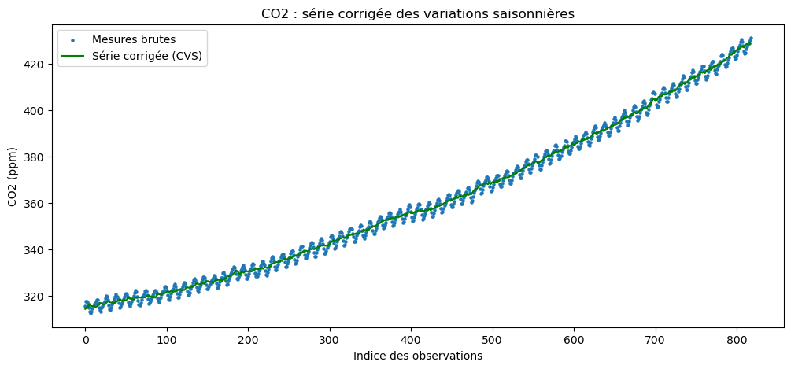

|  | month | average | mm | S | CVS |
| --- | --- | --- | --- | --- | --- |
| 0 | 3 | 315.71 | NaN | NaN | 314.275832 |
| 1 | 4 | 317.45 | NaN | NaN | 314.862206 |
| 2 | 5 | 317.51 | NaN | NaN | 314.472940 |
| 3 | 6 | 317.27 | NaN | NaN | 314.934650 |
| 4 | 7 | 315.87 | NaN | NaN | 315.212424 |
| 5 | 8 | 314.93 | NaN | NaN | 316.453805 |
| 6 | 9 | 313.21 | 315.409167 | -2.199167 | 316.385511 |
| 7 | 10 | 312.42 | 315.459583 | -3.039583 | 315.671461 |
| 8 | 11 | 313.33 | 315.503333 | -2.173333 | 315.378705 |
| 9 | 12 | 314.67 | 315.572500 | -0.902500 | 315.531379 |

```python
co2['CVS'] = co2['average'] - co2['month'].map(coeff_corriges)

plt.figure(figsize=(12, 5))
plt.scatter(range(len(co2)), co2['average'], s=5, label="Mesures brutes")
plt.plot(range(len(co2)), co2['CVS'], color='green', label="Série corrigée (CVS)")
plt.title("CO2 : série corrigée des variations saisonnières")
plt.xlabel("Indice des observations")
plt.ylabel("CO2 (ppm)")
plt.legend()
plt.show()

co2.head(10)
```

On retire à chaque mesure le coefficient corrigé correspondant à son mois. Cela enlève l'effet de la saison de chaque point. Sur le graphique, la série corrigée (en vert) est beaucoup plus lisse que les mesures brutes (en bleu) : les dents de scie ont disparu et il ne reste que la montée régulière. Cette série représente l'évolution du CO₂ "sans les saisons", ce qui permet de mieux voir la tendance de fond.

```
Équation de la droite : y = 0.1388 * t + 304.3316
```

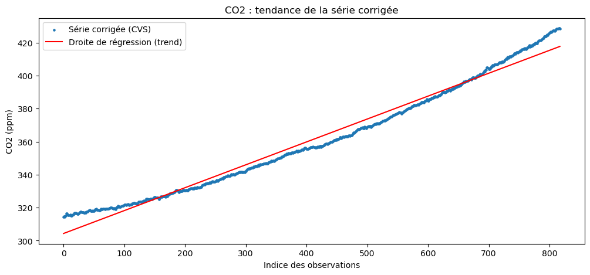

```python
from sklearn.linear_model import LinearRegression

# Régression linéaire sur la série corrigée
X = np.array(range(len(co2))).reshape(-1, 1)
y = co2['CVS'].values

modele = LinearRegression()
modele.fit(X, y)

a = modele.coef_[0]
b = modele.intercept_
print(f"Équation de la droite : y = {a:.4f} * t + {b:.4f}")

# Représentation
plt.figure(figsize=(12, 5))
plt.scatter(range(len(co2)), co2['CVS'], s=5, label="Série corrigée (CVS)")
plt.plot(range(len(co2)), modele.predict(X), color='red', label="Droite de régression (trend)")
plt.title("CO2 : tendance de la série corrigée")
plt.xlabel("Indice des observations")
plt.ylabel("CO2 (ppm)")
plt.legend()
plt.show()
```

On ajuste une droite sur la série corrigée des variations saisonnières. Son équation est y= 0.1388t+ 304.33 La pente (0.1388) indique que le CO₂ augmente en moyenne d'environ 0.14 ppm par mois, soit à peu près 1.7 ppm par an. Cette droite, appelée "trend" ou tendance, résume la croissance de fond du CO₂ sur toute la période, une fois les saisons retirées. On remarque que la série réelle est légèrement courbée et accélère vers la fin : l'augmentation du CO₂ n'est donc pas parfaitement linéaire, mais la droite en donne une bonne approximation générale.

```python
# Prévisions pour les 24 prochains mois
n = len(co2)
indices_futurs = range(n, n + 24)

dernier_mois = co2['month'].iloc[-1]

previsions = []
for i, t in enumerate(indices_futurs):
    mois = (dernier_mois + i) % 12 + 1
    tendance = a * t + b
    valeur = tendance + coeff_corriges[mois]
    previsions.append({'indice': t, 'mois': mois, 'prevision': valeur})

prev_co2 = pd.DataFrame(previsions)
prev_co2
```

|  | indice | mois | prevision |
| --- | --- | --- | --- |
| 0 | 818 | 5 | 420.882843 |
| 1 | 819 | 6 | 420.319903 |
| 2 | 820 | 7 | 418.780900 |
| 3 | 821 | 8 | 416.738290 |
| 4 | 822 | 9 | 415.225354 |
| 5 | 823 | 10 | 415.288174 |
| 6 | 824 | 11 | 416.629700 |
| 7 | 825 | 12 | 417.955797 |
| 8 | 826 | 1 | 419.037142 |
| 9 | 827 | 2 | 419.822436 |
| 10 | 828 | 3 | 420.667655 |
| 11 | 829 | 4 | 421.960051 |
| 12 | 830 | 5 | 422.548088 |
| 13 | 831 | 6 | 421.985148 |
| 14 | 832 | 7 | 420.446145 |
| 15 | 833 | 8 | 418.403534 |
| 16 | 834 | 9 | 416.890599 |
| 17 | 835 | 10 | 416.953419 |
| 18 | 836 | 11 | 418.294945 |
| 19 | 837 | 12 | 419.621042 |
| 20 | 838 | 1 | 420.702387 |
| 21 | 839 | 2 | 421.487681 |
| 22 | 840 | 3 | 422.332900 |
| 23 | 841 | 4 | 423.625296 |

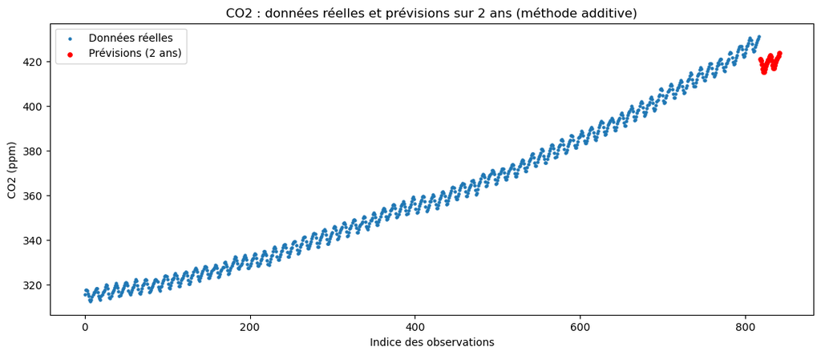

```python
# Visualisation : données réelles + prévisions
plt.figure(figsize=(13, 5))
plt.scatter(range(len(co2)), co2['average'], s=5, label="Données réelles")
plt.scatter(prev_co2['indice'], prev_co2['prevision'], s=15, color='red', label="Prévisions (2 ans)")
plt.title("CO2 : données réelles et prévisions sur 2 ans (méthode additive)")
plt.xlabel("Indice des observations")
plt.ylabel("CO2 (ppm)")
plt.legend()
plt.show()
```

```
Équation du trend CH4 : y = 0.4871 * t + 1661.2640
```

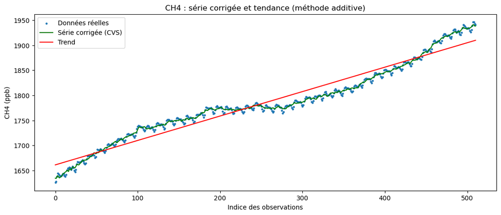

```python
# ===== DÉCOMPOSITION ADDITIVE DU CH4 =====

# 1. Moyenne mobile d'ordre 6
x = ch4['average'].values
n = len(x)
mm = [None] * n
for t in range(6, n - 6):
    valeur = (0.5*x[t-6] + x[t-5] + x[t-4] + x[t-3] + x[t-2] + x[t-1]
              + x[t] + x[t+1] + x[t+2] + x[t+3] + x[t+4] + x[t+5] + 0.5*x[t+6])
    mm[t] = valeur / 12
ch4['mm'] = mm

# 2. Série privée de sa série lissée
ch4['S'] = ch4['average'] - ch4['mm']

# 3. Coefficients mensuels
coeff_ch4 = ch4.groupby('month')['S'].mean()

# 4. Coefficients corrigés
coeff_ch4_corriges = coeff_ch4 - coeff_ch4.mean()

# 5. Série corrigée des variations saisonnières
ch4['CVS'] = ch4['average'] - ch4['month'].map(coeff_ch4_corriges)

# 6. Droite de régression sur la CVS
X = np.array(range(len(ch4))).reshape(-1, 1)
y = ch4['CVS'].values
modele_ch4 = LinearRegression()
modele_ch4.fit(X, y)
a_ch4 = modele_ch4.coef_[0]
b_ch4 = modele_ch4.intercept_
print(f"Équation du trend CH4 : y = {a_ch4:.4f} * t + {b_ch4:.4f}")

# Graphique : données + tendance
plt.figure(figsize=(13, 5))
plt.scatter(range(len(ch4)), ch4['average'], s=5, label="Données réelles")
plt.plot(range(len(ch4)), ch4['CVS'], color='green', label="Série corrigée (CVS)")
plt.plot(range(len(ch4)), modele_ch4.predict(X), color='red', label="Trend")
plt.title("CH4 : série corrigée et tendance (méthode additive)")
plt.xlabel("Indice des observations")
plt.ylabel("CH4 (ppb)")
plt.legend()
plt.show()
```

On applique au CH4 la même méthode que pour le CO₂ : moyenne mobile, série corrigée des variations saisonnières, puis droite de régression. L'équation du trend est y=0.4871 t+1661.26, ce qui correspond à une hausse moyenne d'environ 0.49 ppb par mois. On remarque cependant que la série corrigée n'est pas régulière : le CH4 augmente vite au début, marque un net ralentissement (un plateau) au milieu de la période, puis réaccélère ensuite. La droite de régression représente mal ce comportement, car la tendance du CH4 n'est pas linéaire. La méthode additive reste applicable, mais la droite donne ici une approximation plus grossière que pour le CO₂.

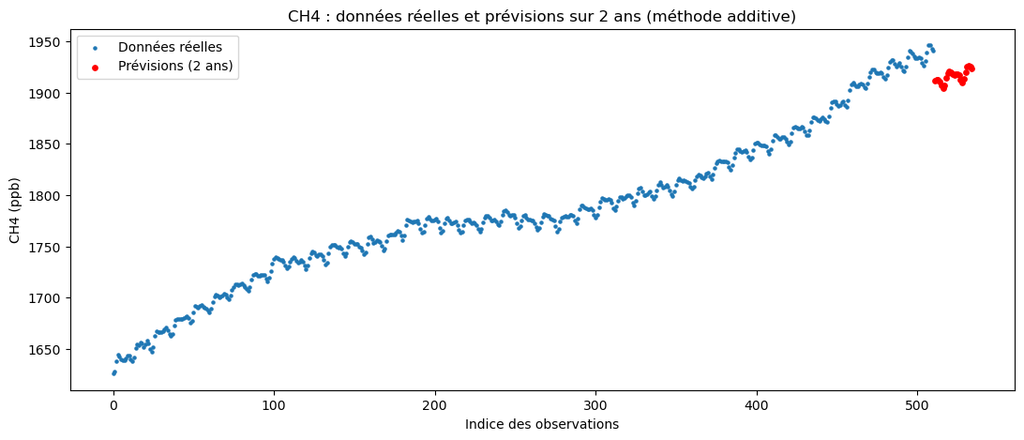

|  | indice | mois | prevision |
| --- | --- | --- | --- |
| 0 | 511 | 2 | 1911.272195 |
| 1 | 512 | 3 | 1911.947651 |
| 2 | 513 | 4 | 1912.344812 |
| 3 | 514 | 5 | 1910.654365 |
| 4 | 515 | 6 | 1906.665346 |
| 5 | 516 | 7 | 1903.861337 |
| 6 | 517 | 8 | 1907.035208 |
| 7 | 518 | 9 | 1914.234697 |
| 8 | 519 | 10 | 1919.147703 |
| 9 | 520 | 11 | 1920.246389 |
| 10 | 521 | 12 | 1919.355543 |
| 11 | 522 | 1 | 1917.708027 |
| 12 | 523 | 2 | 1917.117897 |
| 13 | 524 | 3 | 1917.793352 |
| 14 | 525 | 4 | 1918.190514 |
| 15 | 526 | 5 | 1916.500066 |
| 16 | 527 | 6 | 1912.511047 |
| 17 | 528 | 7 | 1909.707038 |
| 18 | 529 | 8 | 1912.880909 |
| 19 | 530 | 9 | 1920.080399 |
| 20 | 531 | 10 | 1924.993404 |
| 21 | 532 | 11 | 1926.092091 |
| 22 | 533 | 12 | 1925.201245 |
| 23 | 534 | 1 | 1923.553728 |

```python
# Prévisions CH4 sur 24 mois (méthode additive)
n = len(ch4)
dernier_mois = ch4['month'].iloc[-1]

previsions = []
for i, t in enumerate(range(n, n + 24)):
    mois = (dernier_mois + i) % 12 + 1
    tendance = a_ch4 * t + b_ch4
    valeur = tendance + coeff_ch4_corriges[mois]
    previsions.append({'indice': t, 'mois': mois, 'prevision': valeur})

prev_ch4 = pd.DataFrame(previsions)

# Graphique
plt.figure(figsize=(13, 5))
plt.scatter(range(len(ch4)), ch4['average'], s=5, label="Données réelles")
plt.scatter(prev_ch4['indice'], prev_ch4['prevision'], s=15, color='red', label="Prévisions (2 ans)")
plt.title("CH4 : données réelles et prévisions sur 2 ans (méthode additive)")
plt.xlabel("Indice des observations")
plt.ylabel("CH4 (ppb)")
plt.legend()
plt.show()

prev_ch4
```

Question 6 — Décomposition multiplicative

```
Coefficients mensuels corrigés (CO2) :
month
1     1.000193
2     1.001998
3     1.003988
4     1.007192
5     1.008447
6     1.006506
7     1.001880
8     0.995821
9     0.991188
10    0.990946
11    0.994269
12    0.997571
Name: S_mult, dtype: float64
```

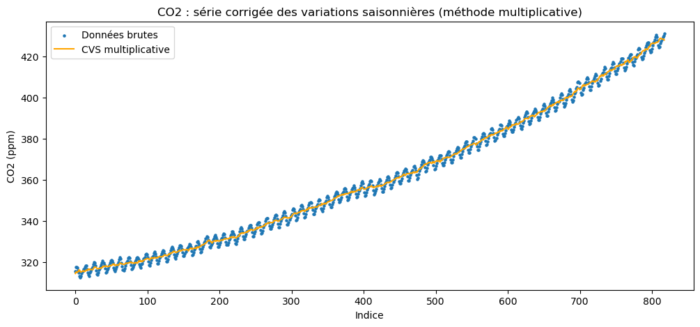

```python
# ===== DÉCOMPOSITION MULTIPLICATIVE — CO2 =====

# 1. On définit la série lissée
x = co2['average'].values
n = len(x)
mm_mult = [None] * n
for t in range(6, n - 6):
    valeur = (0.5*x[t-6] + x[t-5] + x[t-4] + x[t-3] + x[t-2] + x[t-1]
              + x[t] + x[t+1] + x[t+2] + x[t+3] + x[t+4] + x[t+5] + 0.5*x[t+6])
    mm_mult[t] = valeur / 12

co2['mm_mult'] = mm_mult

# 2. Calculer la série divisée par sa série lissée : St = xt / x*t
co2['S_mult'] = co2['average'] / co2['mm_mult']

# 3. Coefficients mensuels
coeff_mult_co2 = co2.groupby('month')['S_mult'].mean()

# 4. Coefficients corrigés : c'j = cj / c_barre
c_barre_co2 = coeff_mult_co2.mean()
coeff_mult_co2_corriges = coeff_mult_co2 / c_barre_co2

print("Coefficients mensuels corrigés (CO2) :")
print(coeff_mult_co2_corriges)

# 5. Série corrigée des variations saisonnières
co2['CVS_mult'] = co2['average'] / co2['month'].map(coeff_mult_co2_corriges)

plt.figure(figsize=(12, 5))
plt.scatter(range(len(co2)), co2['average'], s=5, label="Données brutes")
plt.plot(range(len(co2)), co2['CVS_mult'], color='orange', label="CVS multiplicative")
plt.title("CO2 : série corrigée des variations saisonnières (méthode multiplicative)")
plt.xlabel("Indice")
plt.ylabel("CO2 (ppm)")
plt.legend()
plt.show()
```

La série corrigée (en orange) est plus lisse que les données brutes. Les coefficients mensuels corrigés sont tous très proches de 1 : un coefficient supérieur à 1 signifie que le mois est au-dessus de la tendance (ex : mai à 1.008), un coefficient inférieur à 1 qu'il est en dessous (ex : octobre à 0.990). Dans la méthode multiplicative, la saisonnalité s'exprime en proportion de la tendance plutôt qu'en valeur absolue.

```
Trend CO2 multiplicatif : y = 0.1388t + 304.33
```

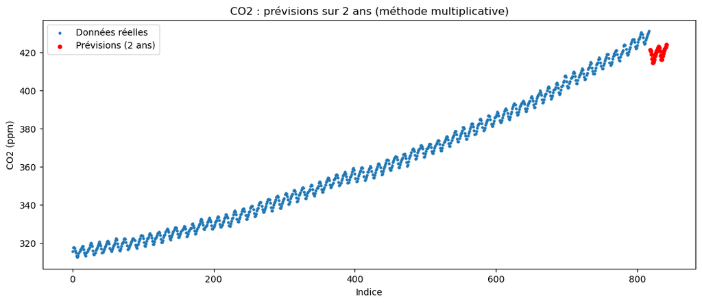

|  | indice | mois | prevision |
| --- | --- | --- | --- |
| 0 | 818 | 5 | 421.375046 |
| 1 | 819 | 6 | 420.703608 |
| 2 | 820 | 7 | 418.909229 |
| 3 | 821 | 8 | 416.513960 |
| 4 | 822 | 9 | 414.713694 |
| 5 | 823 | 10 | 414.749933 |
| 6 | 824 | 11 | 416.278654 |
| 7 | 825 | 12 | 417.799648 |
| 8 | 826 | 1 | 419.036672 |
| 9 | 827 | 2 | 419.931788 |
| 10 | 828 | 3 | 420.905311 |
| 11 | 829 | 4 | 422.388201 |
| 12 | 830 | 5 | 423.054332 |
| 13 | 831 | 6 | 422.379661 |
| 14 | 832 | 7 | 420.577580 |
| 15 | 833 | 8 | 418.172220 |
| 16 | 834 | 9 | 416.364240 |
| 17 | 835 | 10 | 416.400076 |
| 18 | 836 | 11 | 417.934329 |
| 19 | 837 | 12 | 419.460822 |
| 20 | 838 | 1 | 420.702214 |
| 21 | 839 | 2 | 421.600334 |
| 22 | 840 | 3 | 422.577172 |
| 23 | 841 | 4 | 424.065397 |

```python
# 6. Droite de régression sur la CVS multiplicative (CO2)
from sklearn.linear_model import LinearRegression

X = np.array(range(len(co2))).reshape(-1, 1)
y = co2['CVS_mult'].values

modele_mult_co2 = LinearRegression()
modele_mult_co2.fit(X, y)

a_mult_co2 = modele_mult_co2.coef_[0]
b_mult_co2 = modele_mult_co2.intercept_
print(f"Trend CO2 multiplicatif : y = {a_mult_co2:.4f}t + {b_mult_co2:.2f}")

# 7. Prévisions 24 mois
n = len(co2)
dernier_mois = co2['month'].iloc[-1]

previsions = []
for i, t in enumerate(range(n, n + 24)):
    mois = (dernier_mois + i) % 12 + 1
    tendance = a_mult_co2 * t + b_mult_co2
    valeur = tendance * coeff_mult_co2_corriges[mois]
    previsions.append({'indice': t, 'mois': mois, 'prevision': valeur})

prev_co2_mult = pd.DataFrame(previsions)

plt.figure(figsize=(13, 5))
plt.scatter(range(len(co2)), co2['average'], s=5, label="Données réelles")
plt.scatter(prev_co2_mult['indice'], prev_co2_mult['prevision'], s=15, color='red', label="Prévisions (2 ans)")
plt.title("CO2 : prévisions sur 2 ans (méthode multiplicative)")
plt.xlabel("Indice")
plt.ylabel("CO2 (ppm)")
plt.legend()
plt.show()

prev_co2_mult
```

```
Coefficients mensuels corrigés (CH4) :
month
1     1.001211
2     1.000610
3     1.000718
4     1.000668
5     0.999449
6     0.996941
7     0.995090
8     0.996579
9     1.000345
10    1.002825
11    1.003164
12    1.002399
Name: S_mult, dtype: float64
Trend CH4 multiplicatif : y = 0.4871t + 1661.26
```

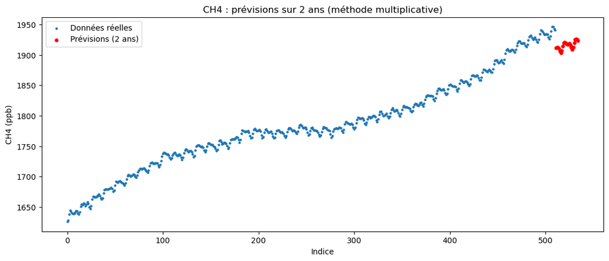

|  | indice | mois | prevision |
| --- | --- | --- | --- |
| 0 | 511 | 2 | 1911.356618 |
| 1 | 512 | 3 | 1912.049804 |
| 2 | 513 | 4 | 1912.442732 |
| 3 | 514 | 5 | 1910.598597 |
| 4 | 515 | 6 | 1906.290247 |
| 5 | 516 | 7 | 1903.235162 |
| 6 | 517 | 8 | 1906.569729 |
| 7 | 518 | 9 | 1914.261340 |
| 8 | 519 | 10 | 1919.496124 |
| 9 | 520 | 11 | 1920.633749 |
| 10 | 521 | 12 | 1919.655697 |
| 11 | 522 | 1 | 1917.869704 |
| 12 | 523 | 2 | 1917.205823 |
| 13 | 524 | 3 | 1917.899638 |
| 14 | 525 | 4 | 1918.292277 |
| 15 | 526 | 5 | 1916.441011 |
| 16 | 527 | 6 | 1912.118003 |
| 17 | 528 | 7 | 1909.052095 |
| 18 | 529 | 8 | 1912.395370 |
| 19 | 530 | 9 | 1920.108995 |
| 20 | 531 | 10 | 1925.358277 |
| 21 | 532 | 11 | 1926.497884 |
| 22 | 533 | 12 | 1925.515356 |
| 23 | 534 | 1 | 1923.722422 |

```python
# ===== DÉCOMPOSITION MULTIPLICATIVE — CH4 =====

# 1. Série lissée
x = ch4['average'].values
n = len(x)
mm_mult = [None] * n
for t in range(6, n - 6):
    valeur = (0.5*x[t-6] + x[t-5] + x[t-4] + x[t-3] + x[t-2] + x[t-1]
              + x[t] + x[t+1] + x[t+2] + x[t+3] + x[t+4] + x[t+5] + 0.5*x[t+6])
    mm_mult[t] = valeur / 12

ch4['mm_mult'] = mm_mult

# 2. St = xt / x*t
ch4['S_mult'] = ch4['average'] / ch4['mm_mult']

# 3. Coefficients mensuels
coeff_mult_ch4 = ch4.groupby('month')['S_mult'].mean()

# 4. Coefficients corrigés
c_barre_ch4 = coeff_mult_ch4.mean()
coeff_mult_ch4_corriges = coeff_mult_ch4 / c_barre_ch4

print("Coefficients mensuels corrigés (CH4) :")
print(coeff_mult_ch4_corriges)

# 5. Série CVS
ch4['CVS_mult'] = ch4['average'] / ch4['month'].map(coeff_mult_ch4_corriges)

# 6. Trend
X = np.array(range(len(ch4))).reshape(-1, 1)
y = ch4['CVS_mult'].values
modele_mult_ch4 = LinearRegression()
modele_mult_ch4.fit(X, y)
a_mult_ch4 = modele_mult_ch4.coef_[0]
b_mult_ch4 = modele_mult_ch4.intercept_
print(f"Trend CH4 multiplicatif : y = {a_mult_ch4:.4f}t + {b_mult_ch4:.2f}")

# 7. Prévisions 24 mois
n = len(ch4)
dernier_mois = ch4['month'].iloc[-1]

previsions = []
for i, t in enumerate(range(n, n + 24)):
    mois = (dernier_mois + i) % 12 + 1
    tendance = a_mult_ch4 * t + b_mult_ch4
    valeur = tendance * coeff_mult_ch4_corriges[mois]
    previsions.append({'indice': t, 'mois': mois, 'prevision': valeur})

prev_ch4_mult = pd.DataFrame(previsions)

plt.figure(figsize=(13, 5))
plt.scatter(range(len(ch4)), ch4['average'], s=5, label="Données réelles")
plt.scatter(prev_ch4_mult['indice'], prev_ch4_mult['prevision'], s=15, color='red', label="Prévisions (2 ans)")
plt.title("CH4 : prévisions sur 2 ans (méthode multiplicative)")
plt.xlabel("Indice")
plt.ylabel("CH4 (ppb)")
plt.legend()
plt.show()

prev_ch4_mult
```

7 — Comparaison des méthodes additive et multiplicative

Dans la méthode additive, on suppose que l'amplitude des variations saisonnières est constante au fil du temps : on ajoute ou soustrait un écart fixe à la tendance.

Dans la méthode multiplicative, on suppose que cette amplitude est proportionnelle au niveau de la tendance : elle grandit en même temps que les valeurs augmentent.

Pour le CO₂ et le CH₄, les données augmentent régulièrement depuis des décennies. En observant les graphiques, l'amplitude des oscillations saisonnières semble rester relativement stable, ce qui favorise légèrement le modèle additif. Cependant, les deux méthodes donnent des résultats très proches ici car les coefficients multiplicatifs sont tous très proches de 1 (entre 0.99 et 1.01), ce qui signifie que la saisonnalité est faible par rapport au niveau général. Le modèle additif est donc légèrement plus pertinent dans ce contexte

Question 8 — Régression linéaire et exponentielle pour N₂O et SF₆

```
Coefficient de corrélation N2O : 0.9966
Droite de régression N2O : y = 0.0791t + 314.72
```

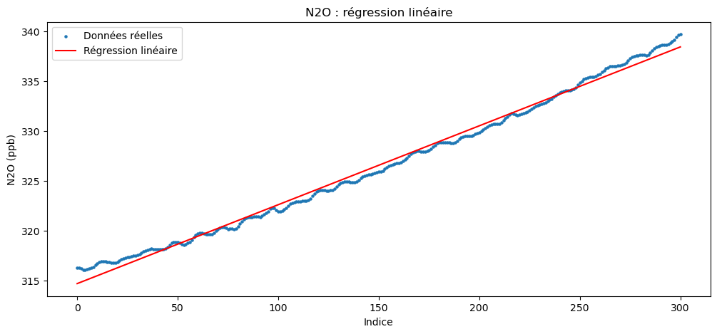

```
    indice  mois   prevision
0      301     2  338.539083
1      302     3  338.618229
2      303     4  338.697375
3      304     5  338.776522
4      305     6  338.855668
5      306     7  338.934814
6      307     8  339.013960
7      308     9  339.093106
8      309    10  339.172253
9      310    11  339.251399
10     311    12  339.330545
11     312     1  339.409691
12     313     2  339.488837
13     314     3  339.567984
14     315     4  339.647130
15     316     5  339.726276
16     317     6  339.805422
17     318     7  339.884568
18     319     8  339.963715
19     320     9  340.042861
20     321    10  340.122007
21     322    11  340.201153
22     323    12  340.280299
23     324     1  340.359446
```

```python
# ===== RÉGRESSION LINÉAIRE — N2O =====

x_n2o = np.array(range(len(n2o)))
y_n2o = n2o['average'].values

# Coefficient de corrélation
r_n2o = np.corrcoef(x_n2o, y_n2o)[0, 1]
print(f"Coefficient de corrélation N2O : {r_n2o:.4f}")

# Droite de régression
X = x_n2o.reshape(-1, 1)
modele_n2o = LinearRegression()
modele_n2o.fit(X, y_n2o)
a_n2o = modele_n2o.coef_[0]
b_n2o = modele_n2o.intercept_
print(f"Droite de régression N2O : y = {a_n2o:.4f}t + {b_n2o:.2f}")

# Graphique
plt.figure(figsize=(12, 5))
plt.scatter(x_n2o, y_n2o, s=5, label="Données réelles")
plt.plot(x_n2o, a_n2o * x_n2o + b_n2o, color='red', label="Régression linéaire")
plt.title("N2O : régression linéaire")
plt.xlabel("Indice")
plt.ylabel("N2O (ppb)")
plt.legend()
plt.show()

# Prévisions 24 mois
n = len(n2o)
prev_n2o_lin = [{'indice': t, 'mois': (n2o['month'].iloc[-1] + i) % 12 + 1,
                 'prevision': a_n2o * t + b_n2o}
                for i, t in enumerate(range(n, n + 24))]
prev_n2o_lin = pd.DataFrame(prev_n2o_lin)
print(prev_n2o_lin)
```

```
Régression exponentielle N2O : y = 314.8727 * e^(0.000242t)
R² linéaire N2O  : 0.993147
R² exponentiel N2O : 0.994506
```

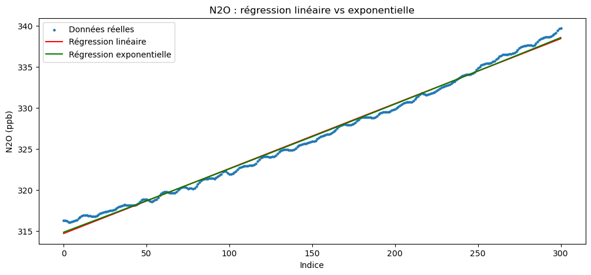

```
    indice  mois   prevision
0      301     2  338.670306
1      302     3  338.752293
2      303     4  338.834300
3      304     5  338.916326
4      305     6  338.998373
5      306     7  339.080439
6      307     8  339.162525
7      308     9  339.244631
8      309    10  339.326757
9      310    11  339.408902
10     311    12  339.491068
11     312     1  339.573253
12     313     2  339.655459
13     314     3  339.737684
14     315     4  339.819929
15     316     5  339.902194
16     317     6  339.984479
17     318     7  340.066784
18     319     8  340.149109
19     320     9  340.231454
20     321    10  340.313818
21     322    11  340.396203
22     323    12  340.478608
23     324     1  340.561032
```

```python
# ===== RÉGRESSION EXPONENTIELLE — N2O =====

# On linéarise : ln(y) = ln(a) + b*t
log_y_n2o = np.log(y_n2o)

modele_exp_n2o = LinearRegression()
modele_exp_n2o.fit(X, log_y_n2o)

b_exp_n2o = modele_exp_n2o.coef_[0]
ln_a_n2o = modele_exp_n2o.intercept_
a_exp_n2o = np.exp(ln_a_n2o)
print(f"Régression exponentielle N2O : y = {a_exp_n2o:.4f} * e^({b_exp_n2o:.6f}t)")

# R² pour comparer les deux modèles
from sklearn.metrics import r2_score
r2_lin_n2o = r2_score(y_n2o, a_n2o * x_n2o + b_n2o)
r2_exp_n2o = r2_score(y_n2o, a_exp_n2o * np.exp(b_exp_n2o * x_n2o))
print(f"R² linéaire N2O  : {r2_lin_n2o:.6f}")
print(f"R² exponentiel N2O : {r2_exp_n2o:.6f}")

# Graphique
plt.figure(figsize=(12, 5))
plt.scatter(x_n2o, y_n2o, s=5, label="Données réelles")
plt.plot(x_n2o, a_n2o * x_n2o + b_n2o, color='red', label="Régression linéaire")
plt.plot(x_n2o, a_exp_n2o * np.exp(b_exp_n2o * x_n2o), color='green', label="Régression exponentielle")
plt.title("N2O : régression linéaire vs exponentielle")
plt.xlabel("Indice")
plt.ylabel("N2O (ppb)")
plt.legend()
plt.show()

# Prévisions 24 mois
prev_n2o_exp = [{'indice': t, 'mois': (n2o['month'].iloc[-1] + i) % 12 + 1,
                 'prevision': a_exp_n2o * np.exp(b_exp_n2o * t)}
                for i, t in enumerate(range(len(n2o), len(n2o) + 24))]
prev_n2o_exp = pd.DataFrame(prev_n2o_exp)
print(prev_n2o_exp)
```

Pour le N₂O, les deux modèles donnent des résultats très proches (R² linéaire = 0.9931, R² exponentiel = 0.9945). Les deux droites se superposent presque sur le graphique. Le modèle exponentiel est très légèrement meilleur, mais la différence est négligeable. Le modèle linéaire est donc suffisant pour modéliser l'évolution du N₂O.

```
Coefficient de corrélation SF6 : 0.9948
Droite de régression SF6 : y = 0.0247t + 3.46
Régression exponentielle SF6 : y = 4.1237 * e^(0.003325t)
R² linéaire SF6 : 0.989688
R² exponentiel SF6 : 0.997344
```

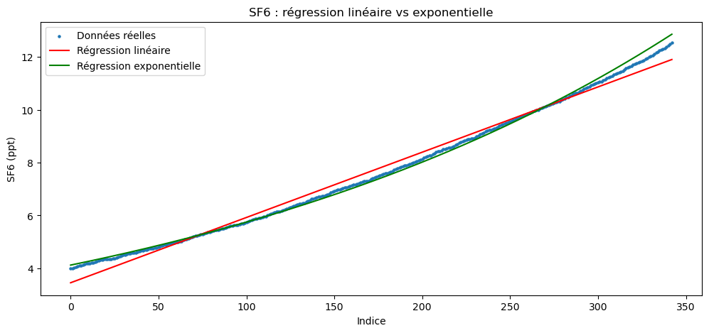

```
    indice  mois  prevision_lin  prevision_exp
0      343     2      11.924043      12.898183
1      344     3      11.948732      12.941136
2      345     4      11.973420      12.984232
3      346     5      11.998108      13.027472
4      347     6      12.022797      13.070855
5      348     7      12.047485      13.114383
6      349     8      12.072174      13.158056
7      350     9      12.096862      13.201874
8      351    10      12.121550      13.245838
9      352    11      12.146239      13.289949
10     353    12      12.170927      13.334207
11     354     1      12.195616      13.378612
12     355     2      12.220304      13.423165
13     356     3      12.244992      13.467866
14     357     4      12.269681      13.512716
15     358     5      12.294369      13.557715
16     359     6      12.319058      13.602864
17     360     7      12.343746      13.648164
18     361     8      12.368434      13.693615
19     362     9      12.393123      13.739216
20     363    10      12.417811      13.784970
21     364    11      12.442500      13.830876
22     365    12      12.467188      13.876935
23     366     1      12.491876      13.923147
```

```python
# ===== RÉGRESSION LINÉAIRE ET EXPONENTIELLE — SF6 =====

x_sf6 = np.array(range(len(sf6)))
y_sf6 = sf6['average'].values

# Coefficient de corrélation
r_sf6 = np.corrcoef(x_sf6, y_sf6)[0, 1]
print(f"Coefficient de corrélation SF6 : {r_sf6:.4f}")

# Régression linéaire
X_sf6 = x_sf6.reshape(-1, 1)
modele_sf6 = LinearRegression()
modele_sf6.fit(X_sf6, y_sf6)
a_sf6 = modele_sf6.coef_[0]
b_sf6 = modele_sf6.intercept_
print(f"Droite de régression SF6 : y = {a_sf6:.4f}t + {b_sf6:.2f}")

# Régression exponentielle
log_y_sf6 = np.log(y_sf6)
modele_exp_sf6 = LinearRegression()
modele_exp_sf6.fit(X_sf6, log_y_sf6)
b_exp_sf6 = modele_exp_sf6.coef_[0]
a_exp_sf6 = np.exp(modele_exp_sf6.intercept_)
print(f"Régression exponentielle SF6 : y = {a_exp_sf6:.4f} * e^({b_exp_sf6:.6f}t)")

# R²
r2_lin_sf6 = r2_score(y_sf6, a_sf6 * x_sf6 + b_sf6)
r2_exp_sf6 = r2_score(y_sf6, a_exp_sf6 * np.exp(b_exp_sf6 * x_sf6))
print(f"R² linéaire SF6 : {r2_lin_sf6:.6f}")
print(f"R² exponentiel SF6 : {r2_exp_sf6:.6f}")

# Graphique
plt.figure(figsize=(12, 5))
plt.scatter(x_sf6, y_sf6, s=5, label="Données réelles")
plt.plot(x_sf6, a_sf6 * x_sf6 + b_sf6, color='red', label="Régression linéaire")
plt.plot(x_sf6, a_exp_sf6 * np.exp(b_exp_sf6 * x_sf6), color='green', label="Régression exponentielle")
plt.title("SF6 : régression linéaire vs exponentielle")
plt.xlabel("Indice")
plt.ylabel("SF6 (ppt)")
plt.legend()
plt.show()

# Prévisions 24 mois
n = len(sf6)
prev_sf6 = [{'indice': t, 'mois': (sf6['month'].iloc[-1] + i) % 12 + 1,
             'prevision_lin': a_sf6 * t + b_sf6,
             'prevision_exp': a_exp_sf6 * np.exp(b_exp_sf6 * t)}
            for i, t in enumerate(range(n, n + 24))]
prev_sf6 = pd.DataFrame(prev_sf6)
print(prev_sf6)
```

Pour le SF₆, on voit clairement sur le graphique que la courbe exponentielle (en vert) colle mieux aux données que la droite linéaire (en rouge), surtout en début et en fin de série. Cela se confirme avec les R² : R² linéaire = 0.9897 vs R² exponentiel = 0.9973. Le modèle exponentiel est donc nettement plus pertinent pour le SF₆, car sa croissance s'accélère légèrement au fil du temps, ce qui est caractéristique d'une croissance exponentielle.

Question 9 — Agrégation annuelle et régressions pour CO₂ et CH₄

```
CO2 annuel :
   year     average  indice
0  1958  315.237000       0
1  1959  315.981667       1
2  1960  316.908333       2
3  1961  317.643333       3
4  1962  318.453333       4

CH4 annuel :
   year      average  indice
0  1983  1636.561667       0
1  1984  1645.011667       1
2  1985  1657.371667       2
3  1986  1670.210833       3
4  1987  1682.803333       4
```

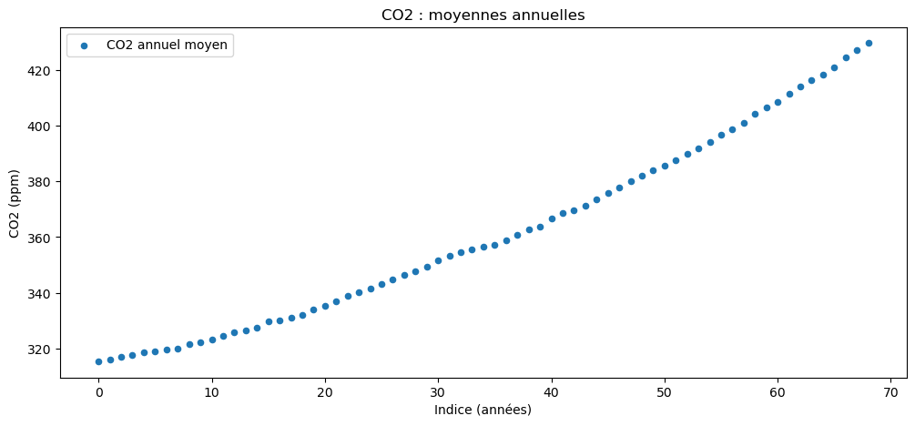

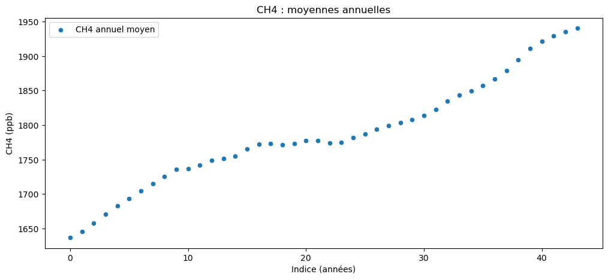

```python
# ===== AGRÉGATION PAR ANNÉE — CO2 =====

# On recharge les données avec la colonne year
co2_raw = pd.read_csv('co2_mm_mlo.csv', comment='#')
ch4_raw = pd.read_csv('ch4_mm_gl.csv', comment='#')

# Agrégation par année (moyenne annuelle)
co2_ann = co2_raw.groupby('year')['average'].mean().reset_index()
ch4_ann = ch4_raw.groupby('year')['average'].mean().reset_index()

# Indice numérique
co2_ann['indice'] = range(len(co2_ann))
ch4_ann['indice'] = range(len(ch4_ann))

print("CO2 annuel :")
print(co2_ann.head())
print("\nCH4 annuel :")
print(ch4_ann.head())

# Nuage de points CO2
plt.figure(figsize=(12, 5))
plt.scatter(co2_ann['indice'], co2_ann['average'], s=20, label="CO2 annuel moyen")
plt.title("CO2 : moyennes annuelles")
plt.xlabel("Indice (années)")
plt.ylabel("CO2 (ppm)")
plt.legend()
plt.show()

# Nuage de points CH4
plt.figure(figsize=(12, 5))
plt.scatter(ch4_ann['indice'], ch4_ann['average'], s=20, label="CH4 annuel moyen")
plt.title("CH4 : moyennes annuelles")
plt.xlabel("Indice (années)")
plt.ylabel("CH4 (ppb)")
plt.legend()
plt.show()
```

```
Corrélation CO2 annuel : 0.9895
Linéaire CO2 : y = 1.6730t + 304.69
Exponentielle CO2 : y = 307.9547 * e^(0.004596t)
R² linéaire CO2 annuel : 0.979093
R² exponentiel CO2 annuel : 0.988895
```

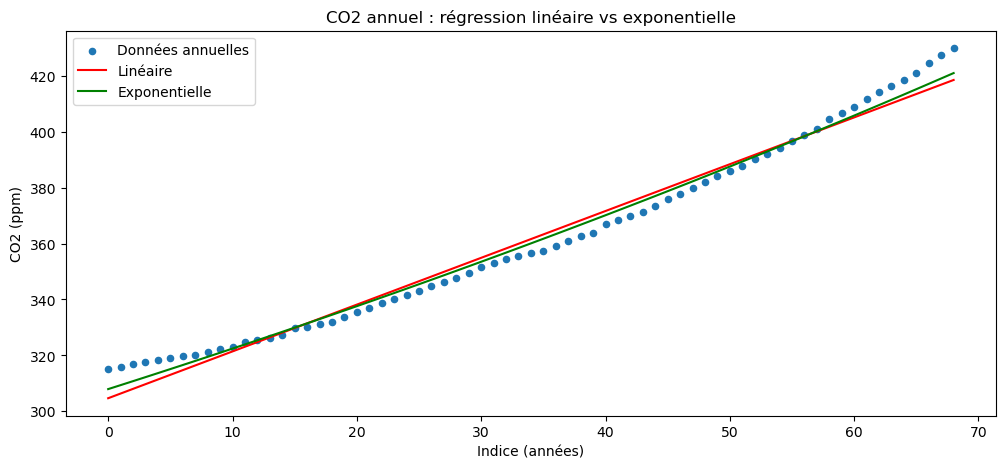

```
CO2 2027 — linéaire : 420.13 ppm | exponentiel : 422.87 ppm
CO2 2028 — linéaire : 421.81 ppm | exponentiel : 424.82 ppm

Corrélation CH4 annuel : 0.9756
Linéaire CH4 : y = 5.9581t + 1658.93
Exponentielle CH4 : y = 1661.9950 * e^(0.003330t)
R² linéaire CH4 annuel : 0.951723
R² exponentiel CH4 annuel : 0.953770
```

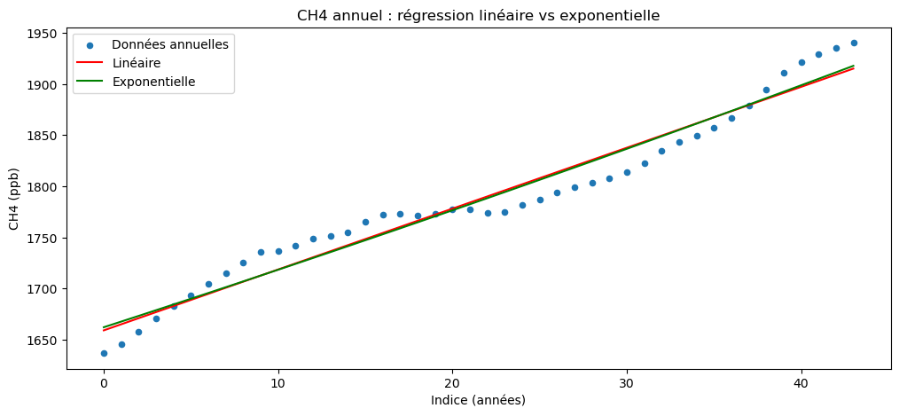

```
CH4 2027 — linéaire : 1921.08 ppb | exponentiel : 1924.26 ppb
CH4 2028 — linéaire : 1927.04 ppb | exponentiel : 1930.68 ppb
```

```python
# ===== RÉGRESSIONS CO2 ANNUEL =====

x_co2_ann = co2_ann['indice'].values
y_co2_ann = co2_ann['average'].values

# Corrélation
r_co2_ann = np.corrcoef(x_co2_ann, y_co2_ann)[0, 1]
print(f"Corrélation CO2 annuel : {r_co2_ann:.4f}")

# Régression linéaire
X_co2_ann = x_co2_ann.reshape(-1, 1)
mod_lin_co2_ann = LinearRegression()
mod_lin_co2_ann.fit(X_co2_ann, y_co2_ann)
a_lin_co2_ann = mod_lin_co2_ann.coef_[0]
b_lin_co2_ann = mod_lin_co2_ann.intercept_
print(f"Linéaire CO2 : y = {a_lin_co2_ann:.4f}t + {b_lin_co2_ann:.2f}")

# Régression exponentielle
mod_exp_co2_ann = LinearRegression()
mod_exp_co2_ann.fit(X_co2_ann, np.log(y_co2_ann))
b_exp_co2_ann = mod_exp_co2_ann.coef_[0]
a_exp_co2_ann = np.exp(mod_exp_co2_ann.intercept_)
print(f"Exponentielle CO2 : y = {a_exp_co2_ann:.4f} * e^({b_exp_co2_ann:.6f}t)")

# R²
r2_lin_co2_ann = r2_score(y_co2_ann, a_lin_co2_ann * x_co2_ann + b_lin_co2_ann)
r2_exp_co2_ann = r2_score(y_co2_ann, a_exp_co2_ann * np.exp(b_exp_co2_ann * x_co2_ann))
print(f"R² linéaire CO2 annuel : {r2_lin_co2_ann:.6f}")
print(f"R² exponentiel CO2 annuel : {r2_exp_co2_ann:.6f}")

# Graphique
plt.figure(figsize=(12, 5))
plt.scatter(x_co2_ann, y_co2_ann, s=20, label="Données annuelles")
plt.plot(x_co2_ann, a_lin_co2_ann * x_co2_ann + b_lin_co2_ann, color='red', label="Linéaire")
plt.plot(x_co2_ann, a_exp_co2_ann * np.exp(b_exp_co2_ann * x_co2_ann), color='green', label="Exponentielle")
plt.title("CO2 annuel : régression linéaire vs exponentielle")
plt.xlabel("Indice (années)")
plt.ylabel("CO2 (ppm)")
plt.legend()
plt.show()

# Prévisions 2 ans
n = len(co2_ann)
for i, t in enumerate(range(n, n + 2)):
    ann = co2_raw['year'].max() + i + 1
    p_lin = a_lin_co2_ann * t + b_lin_co2_ann
    p_exp = a_exp_co2_ann * np.exp(b_exp_co2_ann * t)
    print(f"CO2 {ann} — linéaire : {p_lin:.2f} ppm | exponentiel : {p_exp:.2f} ppm")


# ===== RÉGRESSIONS CH4 ANNUEL =====

x_ch4_ann = ch4_ann['indice'].values
y_ch4_ann = ch4_ann['average'].values

r_ch4_ann = np.corrcoef(x_ch4_ann, y_ch4_ann)[0, 1]
print(f"\nCorrélation CH4 annuel : {r_ch4_ann:.4f}")

X_ch4_ann = x_ch4_ann.reshape(-1, 1)
mod_lin_ch4_ann = LinearRegression()
mod_lin_ch4_ann.fit(X_ch4_ann, y_ch4_ann)
a_lin_ch4_ann = mod_lin_ch4_ann.coef_[0]
b_lin_ch4_ann = mod_lin_ch4_ann.intercept_
print(f"Linéaire CH4 : y = {a_lin_ch4_ann:.4f}t + {b_lin_ch4_ann:.2f}")

mod_exp_ch4_ann = LinearRegression()
mod_exp_ch4_ann.fit(X_ch4_ann, np.log(y_ch4_ann))
b_exp_ch4_ann = mod_exp_ch4_ann.coef_[0]
a_exp_ch4_ann = np.exp(mod_exp_ch4_ann.intercept_)
print(f"Exponentielle CH4 : y = {a_exp_ch4_ann:.4f} * e^({b_exp_ch4_ann:.6f}t)")

r2_lin_ch4_ann = r2_score(y_ch4_ann, a_lin_ch4_ann * x_ch4_ann + b_lin_ch4_ann)
r2_exp_ch4_ann = r2_score(y_ch4_ann, a_exp_ch4_ann * np.exp(b_exp_ch4_ann * x_ch4_ann))
print(f"R² linéaire CH4 annuel : {r2_lin_ch4_ann:.6f}")
print(f"R² exponentiel CH4 annuel : {r2_exp_ch4_ann:.6f}")

plt.figure(figsize=(12, 5))
plt.scatter(x_ch4_ann, y_ch4_ann, s=20, label="Données annuelles")
plt.plot(x_ch4_ann, a_lin_ch4_ann * x_ch4_ann + b_lin_ch4_ann, color='red', label="Linéaire")
plt.plot(x_ch4_ann, a_exp_ch4_ann * np.exp(b_exp_ch4_ann * x_ch4_ann), color='green', label="Exponentielle")
plt.title("CH4 annuel : régression linéaire vs exponentielle")
plt.xlabel("Indice (années)")
plt.ylabel("CH4 (ppb)")
plt.legend()
plt.show()

n = len(ch4_ann)
for i, t in enumerate(range(n, n + 2)):
    ann = ch4_raw['year'].max() + i + 1
    p_lin = a_lin_ch4_ann * t + b_lin_ch4_ann
    p_exp = a_exp_ch4_ann * np.exp(b_exp_ch4_ann * t)
    print(f"CH4 {ann} — linéaire : {p_lin:.2f} ppb | exponentiel : {p_exp:.2f} ppb")
```

Interprétation

**CO₂ annuel** (corrélation = 0.99) : les deux modèles collent bien aux données. Le modèle exponentiel est très légèrement meilleur mais la différence est faible. Les prévisions donnent environ 420-422 ppm en 2027 et 421-424 ppm en 2028.

**CH₄ annuel** (corrélation = 0.9756) : le R² est un peu plus faible car la courbe du CH₄ n'est pas parfaitement linéaire — elle a ralenti entre 1990 et 2006 avant de réaccélérer. Les deux modèles restent proches (R² ≈ 0.95). Le modèle exponentiel est très légèrement plus pertinent.

En agrégeant par année, on supprime les variations saisonnières et on voit uniquement la tendance de fond sur le long terme.